# Prosper Loan Exploratory Data Analysis

## by Mugdha Kamat

## Investigation Overview

> In this investigation, I wanted to look at the characteristics of borrowers that could be used to predict the default on their credit and the factors influencing Prosper rating.

## Dataset Overview

> This investigation is based on a dataset from Prosper, which is America’s first marketplace lending platform, with over 12 billion dollars in funded loans.This data set contains 113,937 loans with 81 variables on each loan, including loan amount, borrower rate (or interest rate), ProsperRating (Alpha), ListingCategory (numeric), Term, current loan status, borrower employment status, StatedMonthlyIncome, DelinquenciesLast7Years, LoanOriginationDate, Recommendations, Investors and TotalProsperLoans. Detailed information of all the variables in this dataset can be found [here.](https://docs.google.com/spreadsheets/d/1gDyi_L4UvIrLTEC6Wri5nbaMmkGmLQBk-Yx3z0XDEtI/edit#gid=0).  
> Prosper starting using Prosper Rating from 2009,so for this analysis, only the datapoints after 2009 have been considered. Also,most of the loans in dataset are actually current loans and hence can not be used to predict default on credit. For this project, Loan Status has been split into just two categories : Completed and Defaulted. So, all the current loans are removed and the chargedoff and defaulted credits are merged together as defaulted.  
> Stated monthly income had an unusually high number of outliers and very large range of values from 0 to 1,750,000. So, all such outliers that are above three standard deviations from the mean are removed.

## Number of Loans by State

> The visualization above clearly shows that most borrowers on Prosper come from California. This is not surprising as Prosper is a San Francisco, CA based company and home of Silicon Valley and it is most likely that this state is more open-minded to new forms of lending.

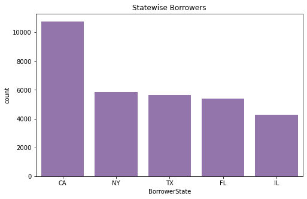

## Borrower Characteristics

> The majority of borrowers are Employed all other categories constitute only a small portion of the borrowers.The histograms above reveal further insights about the borrowers on Prosper. The average EmploymentStatusDuration is about 8 years(100 months) and almost all borrowers indicate a number between 0 and 200 months. Surprisingly, there are also a few borrowers that have been in the same status for more than 500 months (~40 years).

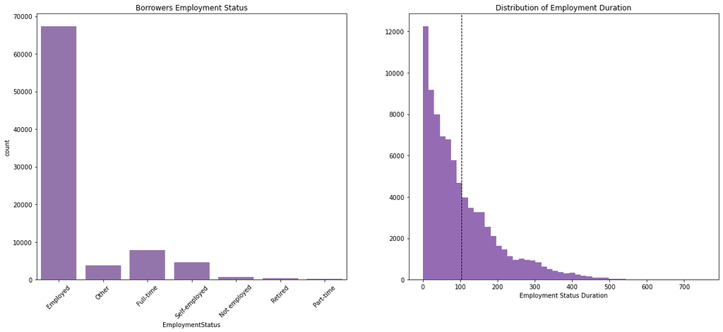

## Distribution of Borrower's Monthly Income

The average StatedMonthlyIncome is slightly above 5,000 USD, which is quite high. The histogram shows a majority of borrowers actually have a monthly income below 5,000 USD. The x-Axis has been limited as some borrowers indicated a monthly income of more than 25.000 USD which were mostly outliers.

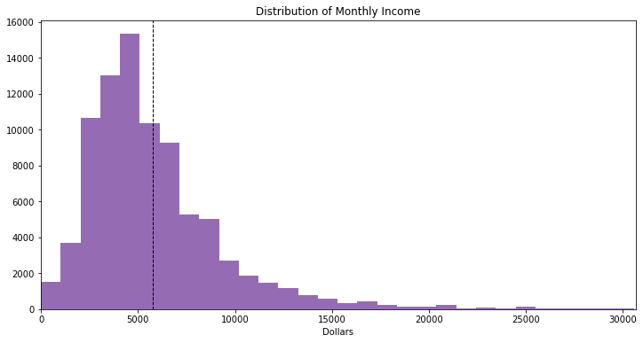

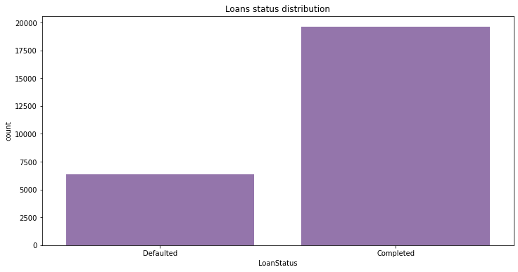

## Distribution of Prosper Rating

ProsperRating is an ordinal categorical variable with the following values from higher to lower.The Ratings were assigned at the time the listing was created: 0 - N/A, 1 - HR, 2 - E, 3 - D, 4 - C, 5 - B, 6 - A, 7 - AA. Interestingly ratings are almost normally distributed with the highest AA rating and the lowest rating HR are the least common and average rating C being the most common.

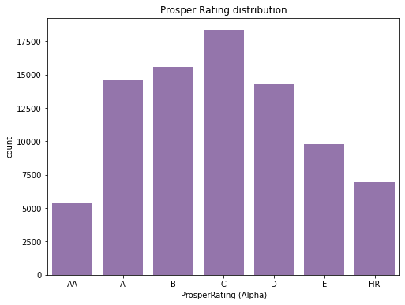

## Loan Status vs Prosper Rating

Now, as seen in the plot, interstingly, only a few borrowers have defaulted loans with Prosper Rating of AA. The proportion of defaulted loans in the lower rating groups are significant higher. For example, in the ‘HR’ group the defaulted loan is more than half of the completed loans.

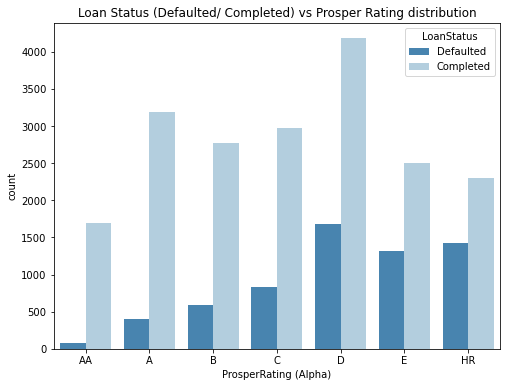

## Loan Status vs Listing Category

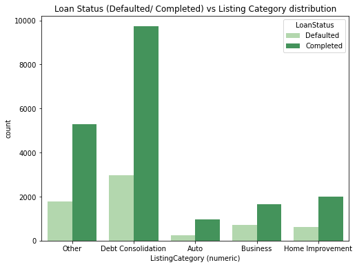

## Prosper Loan Amount

Taking a closer look at the loans funded by the Prosper community. The LoanOriginalAmount plot indicates that borrowers usually ask for an amount less than 15.000 USD, even though there are also loans with much higher amounts. Especially 5,000, 10,000 and 15,000 USD loans are very popular on Prosper.

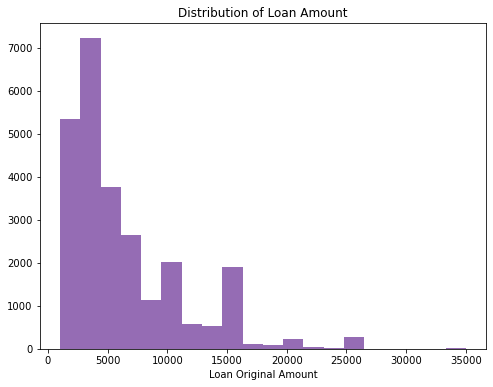

## Prosper Loan characteristics : Term

For Term, the loans time periods, there are three options: 36, 60 and 12 months.Again, the most popular term for the loans among the borrowers in this dataset is 36 months. Also, Long-term (60 months) have the greatest proportion of defaulted credits.

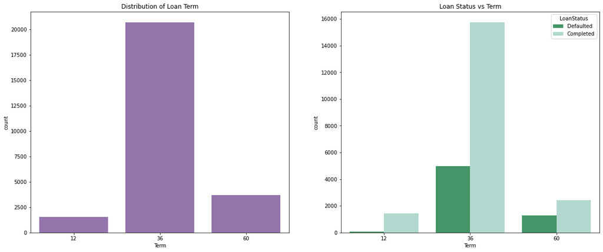

## Monthly Income and Loan Status

The stated income of the borrower group that completed the loan is slightly higher than the other group, though there are a lot of outliers present in both groups.

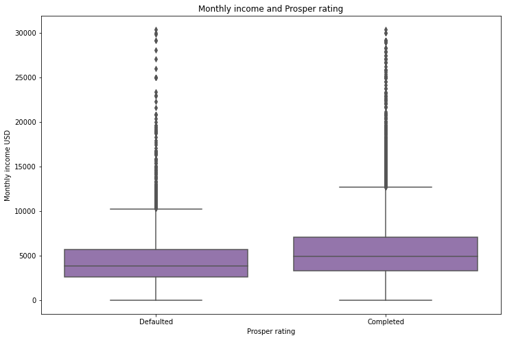

## Prosper Rating vs Monthly Income

As expected, Borrowers with higher Prosper rating tend to have higher monthly income.

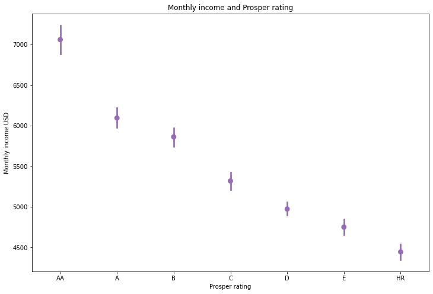

## Prosper Rating, Loan Amount and Loan Status

Borrowers with high Prosper rating tend to borrow more and the ones with low rating on the other hand tend to borrow less. Also, among the high rating borrowers, the defaulted loan amount is higher than the completed, whereas among the low rating borrowers, defaulted credits usually are almost equal as completed.

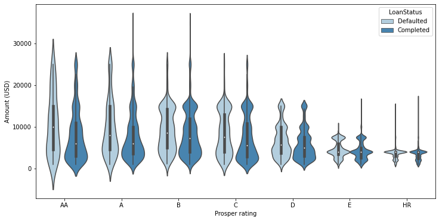